# Homework Three

DACSS 603

Cynthia Hester  
March 20,2022

## Question 1

(SMSS 11.2, except part (d))

For recent data in Jacksonville, Florida, on y = selling price of home (in dollars), x1 = size of home (in square feet), and x2 = lot size (in square feet), the prediction equation is ŷ = −10,536 + 53.8x1 + 2.84x2.

### Solutions

**Part A**

A particular home of 1240 square feet on a lot of 18,000 square feet sold for $145,000. Find the predicted selling price and the residual, and interpret.

Here’s what we have:

The selling price of the home depends on the size of the home and the lot size. Therefore, the selling price of home is the dependent or the response variable. The size of home is the first explanatory variable, and lot size is the second explanatory variable. Therefore,the multiple linear regression of the problem is obtained using the formula:

$Y_{}$ = $B_{0}$ +$B_{1}$ $x_{i1}$ + $B_{2}$$x_{i2}$ + €

where:

$Y_{i}$ = dependent variable that is the selling price of home

$B_{0}$ = the y-intercept

$B_{1}$ and $B_{2}$ are the slopes of the explanatory variables.

$x_{i1}$ is the first explanatory variable that is the size of home

$x_{i2}$ is the second explanatory variable that is the lot size.

€ is the error or residual

where:

$Y_{}$ is the selling price of home.

$x_{1}$ is the size of home

$x_{2}$ is the lot size.

For a home of 1240 square feet on a lot of 18,000 square feet,we predict the selling price with estimated multiple linear regression using the predictive equation:

Calculating selling price in R

```r
 house_selling_price<- -(10536)+53.8*1240+2.84*18000      # selling_price in R
 print(house_selling_price)                               # review of output
```

```
[1] 107296
```

House selling price = $107296

Now we calculate the residual which is the difference between the observed value and the mean value the model predicts for that observation. It is the vertical distance between a data point and the regression line. It is a measure of how well a line fits an individual data point.

```r
residual_house_price<-145000-house_selling_price    #residual price of house
print(residual_house_price)
```

```
[1] 37704
```

#### Interpretation:

Since we have a positive residual value, it means the actual selling price is MORE than the predicted selling price. The house therefore sold for more than was predicted.

**Part B**

For fixed lot size, how much is the house selling price predicted to increase for each square-foot increase in home size? Why?

#### Interpretation:

The slope coefficient for the first explanatory variable **size of the home** is obtained as 53.8 and is positive. For every additional unit increase in the size of the home, the selling price of the home increases by 53.8 sq.ft., keeping the other explanatory variable that is **lot size** fixed.

Thus, for every additional square-foot increase in the size of the home, the selling price of the home increases by $53.80, keeping the other explanatory variable that is **lot size** fixed.

**Part C**

According to this prediction equation, for fixed home size, how much would the lot size need to increase to have the same impact as a one-square-foot increase in home size?

#### Interpretation:

The slope coefficient for the second explanatory variable **lot size** is 2.84 and is positive. For every additional unit increase in the lot size, the selling price of the house increases by 2.84 sq.ft., keeping the other explanatory variable **home size** which is 53.8 fixed. Therefore, taking the equation :

$\hat{y}$ = -10,536+53.8$x_{1}$+2.84$x_{2}$

We multiply lot size 53.8*(1)/2.84 where 1 is the one-square-foot increase in home size and divide by lot size 2.84.

```r
lot_increase<-53.8*1/2.84
print(lot_increase)
```

```
[1] 18.94366
```

19 sq.ft. is the amount the lot size would need to increase to have the same impact as a one-square-foot increase in home size.

## Question 2

(ALR, 5.17, slightly modified)

(Data file: salary in alr4 R package).

The data file concerns salary and other characteristics of all faculty in a small Midwestern college collected in the early 1980s for presentation in legal proceedings for which discrimination against women in salary was at issue. All persons in the data hold tenured or tenure track positions; temporary faculty are not included. The variables include *degree*, a factor with levels PhD and MS; *rank*, a factor with levels Asst, Assoc, and Prof; *sex*, a factor with levels Male and Female; *Year*, years in current rank; *ysdeg*, years since highest degree, and *salary*, academic year salary in dollars.

First, I inspect the data set for an understanding what it is about.

```r
glimpse(salary)
```

```
Rows: 52
Columns: 6
$ degree <fct> Masters, Masters, Masters, Masters, PhD, Masters, PhD~
$ rank   <fct> Prof, Prof, Prof, Prof, Prof, Prof, Prof, Prof, Prof,~
$ sex    <fct> Male, Male, Male, Female, Male, Male, Female, Male, M~
$ year   <int> 25, 13, 10, 7, 19, 16, 0, 16, 13, 13, 12, 15, 9, 9, 9~
$ ysdeg  <int> 35, 22, 23, 27, 30, 21, 32, 18, 30, 31, 22, 19, 17, 2~
$ salary <int> 36350, 35350, 28200, 26775, 33696, 28516, 24900, 3190~
```

```r
summary(salary)
```

```
     degree      rank        sex          year            ysdeg
 Masters:34   Asst :18   Male  :38   Min.   : 0.000   Min.   : 1.00
 PhD    :18   Assoc:14   Female:14   1st Qu.: 3.000   1st Qu.: 6.75
              Prof :20               Median : 7.000   Median :15.50
                                     Mean   : 7.481   Mean   :16.12
                                     3rd Qu.:11.000   3rd Qu.:23.25
                                     Max.   :25.000   Max.   :35.00
     salary
 Min.   :15000
 1st Qu.:18247
 Median :23719
 Mean   :23798
 3rd Qu.:27259
 Max.   :38045
```

```r
head(salary,15)       #First 15 rows of the data set
```

```
    degree  rank    sex year ysdeg salary
1  Masters  Prof   Male   25    35  36350
2  Masters  Prof   Male   13    22  35350
3  Masters  Prof   Male   10    23  28200
4  Masters  Prof Female    7    27  26775
5      PhD  Prof   Male   19    30  33696
6  Masters  Prof   Male   16    21  28516
7      PhD  Prof Female    0    32  24900
8  Masters  Prof   Male   16    18  31909
9      PhD  Prof   Male   13    30  31850
10     PhD  Prof   Male   13    31  32850
11 Masters  Prof   Male   12    22  27025
12 Masters Assoc   Male   15    19  24750
13 Masters  Prof   Male    9    17  28200
14     PhD Assoc   Male    9    27  23712
15 Masters  Prof   Male    9    24  25748
```

### Solutions

**Part A**

Test the hypothesis that the mean salary for men and women is the same, without regard to any other variable but sex. Explain your findings.

First, to gain an understanding of the data, I import the **Salary** data from the **alr4textbook** library.

```r
library(alr4)
data("salary")
dim(salary)
```

```
[1] 52  6
```

```r
library(skimr)
summary(salary)
```

```
     degree      rank        sex          year            ysdeg
 Masters:34   Asst :18   Male  :38   Min.   : 0.000   Min.   : 1.00
 PhD    :18   Assoc:14   Female:14   1st Qu.: 3.000   1st Qu.: 6.75
              Prof :20               Median : 7.000   Median :15.50
                                     Mean   : 7.481   Mean   :16.12
                                     3rd Qu.:11.000   3rd Qu.:23.25
                                     Max.   :25.000   Max.   :35.00
     salary
 Min.   :15000
 1st Qu.:18247
 Median :23719
 Mean   :23798
 3rd Qu.:27259
 Max.   :38045
```

We see that mean salary for men is $24,696.79 and mean salary for women is $21,357.14 a difference of $3339.65.

Now we test the hypothesis

Hypothesis Testing:

$H_{0}$: $=$ mean salaries between men and women are the same

$H_{a}$: $\neq$ there is a difference in mean salaries of men and women

Significance Level = 0.05

Test Statistic = t-test

Now that I have a better understanding of the data, I check whether the variance between men and women is the same.

```r
## Calculating mean salary by sex using pipes and the group_by function

salary %>% group_by(sex) %>%
  summarise(mean = mean(salary),
              sd = sd(salary))
```

```
# A tibble: 2 x 3
  sex      mean    sd
  <fct>   <dbl> <dbl>
1 Male   24697. 5646.
2 Female 21357. 6152.
```

We now use the Two Sample t-test to determine the confidence interval .

```r
t.test(salary~sex, data = salary, var.equal = T,    #t-test to calculate the 95% CI
       conf.level = 0.95, alternative = "two.sided")
```

```
    Two Sample t-test

data:  salary by sex
t = 1.8474, df = 50, p-value = 0.0706
alternative hypothesis: true difference in means between group Male and group Female is not equal to 0
95 percent confidence interval:
 -291.257 6970.550
sample estimates:
  mean in group Male mean in group Female
            24696.79             21357.14
```

#### Interpretation:

The p-value of the **t-test = 0.0706**, therefore at a 5% significance level,there is not enough evidence to reject the null hypothesis $H_{0}$ since the probability of the null hypothesis $H_{0}$ being true is 7.06% higher than the benchmark rejection of 5%. We therefore fail to reject the null hypothesis $H_{0}$ that mean salary for men and women are the same.

**Part B**

Run a multiple linear regression with *salary* as the outcome variable and everything else as predictors, including *sex*. Assuming no interactions between *sex* and the other predictors, obtain a 95% confidence interval for the difference in *salary* between *males and females*.

First, we run a multiple regression model using **salary**.

```r
lm_model <- lm(salary~.,data = salary)    #multiple linear regression
summary(lm_model)                         #review of output
```

```
Call:
lm(formula = salary ~ ., data = salary)

Residuals:
    Min      1Q  Median      3Q     Max
-4045.2 -1094.7  -361.5   813.2  9193.1

Coefficients:
            Estimate Std. Error t value Pr(>|t|)
(Intercept) 15746.05     800.18  19.678  < 2e-16 ***
degreePhD    1388.61    1018.75   1.363    0.180
rankAssoc    5292.36    1145.40   4.621 3.22e-05 ***
rankProf    11118.76    1351.77   8.225 1.62e-10 ***
sexFemale    1166.37     925.57   1.260    0.214
year          476.31      94.91   5.018 8.65e-06 ***
ysdeg        -124.57      77.49  -1.608    0.115
---
Signif. codes:  0 '***' 0.001 '**' 0.01 '*' 0.05 '.' 0.1 ' ' 1

Residual standard error: 2398 on 45 degrees of freedom
Multiple R-squared:  0.855, Adjusted R-squared:  0.8357
F-statistic: 44.24 on 6 and 45 DF,  p-value: < 2.2e-16
```

**Part 2 of B**

**Assuming no interactions between sex and the other predictors, obtain a 95% confidence interval for the difference in salary between males and females.**

I now calculate the 95% confidence interval for the difference between male and female salaries, using a t-test.

```r
t.test(salary~sex, data = salary, var.equal = T,    #t-test to calculate the 95% CI
       conf.level = 0.95, alternative = "two.sided")
```

```
    Two Sample t-test

data:  salary by sex
t = 1.8474, df = 50, p-value = 0.0706
alternative hypothesis: true difference in means between group Male and group Female is not equal to 0
95 percent confidence interval:
 -291.257 6970.550
sample estimates:
  mean in group Male mean in group Female
            24696.79             21357.14
```

95% confidence interval for the difference in salaries between *male and female* is:

**[-291.257 6970.550]** where -291.257 is the lower bound and 6970.550 is the upper bound

Using the summary function and the linear model (lm) we once again see the **significance level or p-value is 0.0706 or 7.06%**. Furthermore, we see the **point estimate** of the *Sex* variable is **$3340** in favor of males.

```r
summary(lm_model <- lm(salary ~ sex, salary))$coef
```

```
             Estimate Std. Error  t value     Pr(>|t|)
(Intercept) 24696.789   937.9776 26.32983 5.761530e-31
sexFemale   -3339.647  1807.7156 -1.84744 7.060394e-02
```

**Part C**

Interpret your finding for each predictor variable; discuss (a) statistical significance, (b) interpretation of the coefficient / slope in relation to the outcome variable and other variables.

Here, I calculate the multiple linear regression to determine the statistical significance of the predictor variables.

```r
lm_model <- lm(salary~.,data = salary)    #multiple linear regression
summary(lm_model)
```

```
Call:
lm(formula = salary ~ ., data = salary)

Residuals:
    Min      1Q  Median      3Q     Max
-4045.2 -1094.7  -361.5   813.2  9193.1

Coefficients:
            Estimate Std. Error t value Pr(>|t|)
(Intercept) 15746.05     800.18  19.678  < 2e-16 ***
degreePhD    1388.61    1018.75   1.363    0.180
rankAssoc    5292.36    1145.40   4.621 3.22e-05 ***
rankProf    11118.76    1351.77   8.225 1.62e-10 ***
sexFemale    1166.37     925.57   1.260    0.214
year          476.31      94.91   5.018 8.65e-06 ***
ysdeg        -124.57      77.49  -1.608    0.115
---
Signif. codes:  0 '***' 0.001 '**' 0.01 '*' 0.05 '.' 0.1 ' ' 1

Residual standard error: 2398 on 45 degrees of freedom
Multiple R-squared:  0.855, Adjusted R-squared:  0.8357
F-statistic: 44.24 on 6 and 45 DF,  p-value: < 2.2e-16
```

#### Interpretation:

**Intercept**: Average salary of a person is estimated to be **$15746.05**, with no impact from any other predictors.

**degreePHD**: For a person holding a PHD degree, there is a positive slope and an average increase in the salary of the person by **$1388.61** keeping all other variables as constant. The p-value is **0.18 > 0.05** therefore not statistically significant.

**rankAssoc**: For a person who holds an associate rank, there is a positive slope and an average increase in the salary of the person by **$5292.36**, keeping all other variables as constant. The p-value is **3.22e-05 < 0.05** and is statistically significant.

**rankProf**: For a person who holds an professor rank, there is a positive slope and an average increase in the salary of the person by **$11118.76**, keeping all other variables as constant. The p-value is **1.62e-10 < 0.05** and is statistically significant.

**year**: For an extra year of person holding same rank, there is a positive slope and an average increase in the salary of **$476.31**, keeping all other variables as constant. The p-value is **8.65e-06 < 0.05** and is statistically significant.

**ysdeg**: For an additional year of holding the highest degree, there is a negative slope and an average decrease in the salary of $124.57, keeping all other variables as constant. The p-value is **0.115 > 0.05** and is not statistically significant.

**Part D**

Change the baseline category for the rank variable. Interpret the coefficients related to rank again.

I first create new dummy variables for the **rank** variable(s).

```r
salary$D1 <- ifelse(salary$rank=="Asst",1,0)
salary$D2 <- ifelse(salary$rank=="Prof",1,0)
```

Revised linear models after changing the base category of **rank**

```r
# Linear Model after changing the base category of rank
lm_model <- lm(salary~degree+D1+D2+sex+year+ysdeg,data = salary)
summary(lm_model)
```

```
Call:
lm(formula = salary ~ degree + D1 + D2 + sex + year + ysdeg,
    data = salary)

Residuals:
    Min      1Q  Median      3Q     Max
-4045.2 -1094.7  -361.5   813.2  9193.1

Coefficients:
            Estimate Std. Error t value Pr(>|t|)
(Intercept) 21038.41    1109.12  18.969  < 2e-16 ***
degreePhD    1388.61    1018.75   1.363    0.180
D1          -5292.36    1145.40  -4.621 3.22e-05 ***
D2           5826.40    1012.93   5.752 7.28e-07 ***
sexFemale    1166.37     925.57   1.260    0.214
year          476.31      94.91   5.018 8.65e-06 ***
ysdeg        -124.57      77.49  -1.608    0.115
---
Signif. codes:  0 '***' 0.001 '**' 0.01 '*' 0.05 '.' 0.1 ' ' 1

Residual standard error: 2398 on 45 degrees of freedom
Multiple R-squared:  0.855, Adjusted R-squared:  0.8357
F-statistic: 44.24 on 6 and 45 DF,  p-value: < 2.2e-16
```

#### Analysis:

Revised Rank variables:

#### D1 = Assistant Rank

D1 = -5292.36 implies that for a person holding an **Assistant Rank**, there is an average decrease in salary by $5292.36 compared to a person holding a **Associate Rank**, keeping all other variables as constant.

#### D2 = Professor Rank

D2 = 5826.40, implies that for a person holding a **Professor Rank**, there is an average increase in the salary of $5826.40 compared to a person holding an **Associate Rank**, keeping all other variables as constant.

**Part E**

Finkelstein (1980), in a discussion of the use of regression in discrimination cases, wrote, “[a] variable may reflect a position or status bestowed by the employer, in which case if there is discrimination in the award of the position or status, the variable may be ‘tainted.’” Thus, for example, if discrimination is at work in promotion of faculty to higher ranks, using rank to adjust salaries before comparing the sexes may not be acceptable to the courts.

Exclude the variable rank, refit, and summarize how your findings changed, if they did.

Excluding the variable *rank* in the linear regression model

```r
#linear regression model using the lm function

lm_model_no_rank<-lm(formula=salary~sex+degree+year+ysdeg,data=salary)
summary(lm_model_no_rank)                       #review of linear model output
```

```
Call:
lm(formula = salary ~ sex + degree + year + ysdeg, data = salary)

Residuals:
    Min      1Q  Median      3Q     Max
-8146.9 -2186.9  -491.5  2279.1 11186.6

Coefficients:
            Estimate Std. Error t value Pr(>|t|)
(Intercept) 17183.57    1147.94  14.969  < 2e-16 ***
sexFemale   -1286.54    1313.09  -0.980 0.332209
degreePhD   -3299.35    1302.52  -2.533 0.014704 *
year          351.97     142.48   2.470 0.017185 *
ysdeg         339.40      80.62   4.210 0.000114 ***
---
Signif. codes:  0 '***' 0.001 '**' 0.01 '*' 0.05 '.' 0.1 ' ' 1

Residual standard error: 3744 on 47 degrees of freedom
Multiple R-squared:  0.6312,    Adjusted R-squared:  0.5998
F-statistic: 20.11 on 4 and 47 DF,  p-value: 1.048e-09
```

#### Interpretation:

Excluding the *rank* variable, the coefficient for *SexFemale* has a negative slope, indicating a salary advantage for males,however, the **𝑝-value is 0.33** which is greater than > 0.05, indicating the difference is not statistically significant.

Excluding the *rank* variable, the coefficient for *year* has a positive slope, indicating a increase a positive relationship to *salary* of approximately $351.97. With a 𝑝-value of 0.017185 which is < less than 0.05 benchmark, this indicates statistical significance.

Excluding the *rank* variable, the coefficient for *ysdeg* has a positive slope, indicating a increase a positive relationship to *salary* of approximately $339.40. With a 𝑝-value of 0.000114 which is < less than 0.05 benchmark, this indicates statistical significance.

#### Analysis:

**Part F**

Everyone in this dataset was hired the year they earned their highest degree. It is also known that a new Dean was appointed 15 years ago, and everyone in the dataset who earned their highest degree 15 years ago or less than that has been hired by the new Dean. Some people have argued that the new Dean has been making offers that are a lot more generous to newly hired faculty than the previous one and that this might explain some of the variation in Salary.

Create a new variable that would allow you to test this hypothesis and run another multiple regression model to test this. Select variables carefully to make sure there is no multicollinearity. Explain why multicollinearity would be a concern in this case and how you avoided it. Do you find support for the hypothesis that the people hired by the new Dean are making higher than those that were not?

Let’s start with our hypotheses

Hypotheses:

$H_{0}$: $>$ Mean salary of hires for new Dean are greater than mean salary of hires of former Dean

$H_{a}$: $\leq$ Mean salary of hires for new Dean are less than or equal to mean salary of former Dean

I now check if there is any multicollinearity in our model

```r
lm_model_ysdeg <- lm(salary~.,data = salary)    #multiple linear regression
summary(lm_model_ysdeg)
```

```
Call:
lm(formula = salary ~ ., data = salary)

Residuals:
    Min      1Q  Median      3Q     Max
-4045.2 -1094.7  -361.5   813.2  9193.1

Coefficients: (2 not defined because of singularities)
            Estimate Std. Error t value Pr(>|t|)
(Intercept) 15746.05     800.18  19.678  < 2e-16 ***
degreePhD    1388.61    1018.75   1.363    0.180
rankAssoc    5292.36    1145.40   4.621 3.22e-05 ***
rankProf    11118.76    1351.77   8.225 1.62e-10 ***
sexFemale    1166.37     925.57   1.260    0.214
year          476.31      94.91   5.018 8.65e-06 ***
ysdeg        -124.57      77.49  -1.608    0.115
D1                NA         NA      NA       NA
D2                NA         NA      NA       NA
---
Signif. codes:  0 '***' 0.001 '**' 0.01 '*' 0.05 '.' 0.1 ' ' 1

Residual standard error: 2398 on 45 degrees of freedom
Multiple R-squared:  0.855, Adjusted R-squared:  0.8357
F-statistic: 44.24 on 6 and 45 DF,  p-value: < 2.2e-16
```

Model would not knit with the *vif* function. However, *Vif* chunk will run when separated from rest of model.

```r
#vif(lm_model_ysdeg)#variance inflation factor (VIF)
```

#### Interpretation:

```r
salary$hires<-ifelse(salary$ysdeg<=15,1,0)  #dummy variable

new_dean<-lm(salary~rank+degree+sex+year+hires,data=salary)
summary(new_dean)                         # review model output
```

```
Call:
lm(formula = salary ~ rank + degree + sex + year + hires, data = salary)

Residuals:
    Min      1Q  Median      3Q     Max
-3403.3 -1387.0  -167.0   528.2  9233.8

Coefficients:
            Estimate Std. Error t value Pr(>|t|)
(Intercept) 13328.38    1483.38   8.985 1.33e-11 ***
rankAssoc    4972.66     997.17   4.987 9.61e-06 ***
rankProf    11096.95    1191.00   9.317 4.54e-12 ***
degreePhD     818.93     797.48   1.027   0.3100
sexFemale     907.14     840.54   1.079   0.2862
year          434.85      78.89   5.512 1.65e-06 ***
hires        2163.46    1072.04   2.018   0.0496 *
---
Signif. codes:  0 '***' 0.001 '**' 0.01 '*' 0.05 '.' 0.1 ' ' 1

Residual standard error: 2362 on 45 degrees of freedom
Multiple R-squared:  0.8594,    Adjusted R-squared:  0.8407
F-statistic: 45.86 on 6 and 45 DF,  p-value: < 2.2e-16
```

#### Analysis:

When the linear model is run omitting the *ysdeg* variable, *year* appears to have a statistically significant p-value of 1.65e-06. Moreover, an adjusted R-squared of 0.8407 indicates a strong correlation. It is important to avoid any multicollinearity in the model because we want a model of independent variables. If the variables are too close when fitting the model we can have skewed results, in other words the variables may not provide unique or independent information.

## Question 3

(SMSS 13.7 & 13.8 combined, modified)

(Data file: house.selling.price in smss R package)

### Solutions

**Part A**

Using the house.selling.price data, run and report regression results modeling y = selling price (in dollars) in terms of size of home (in square feet) and whether the home is new (1 = yes; 0 = no). (In other words, price is the outcome variable and size and new are the explanatory variables.)

I first import the house selling price data and inspect it.

```r
library(smss)
data(house.selling.price)
str(house.selling.price)
```

```
'data.frame':   100 obs. of  7 variables:
 $ case : int  1 2 3 4 5 6 7 8 9 10 ...
 $ Taxes: int  3104 1173 3076 1608 1454 2997 4054 3002 6627 320 ...
 $ Beds : int  4 2 4 3 3 3 3 3 5 3 ...
 $ Baths: int  2 1 2 2 3 2 2 2 4 2 ...
 $ New  : int  0 0 0 0 0 1 0 1 0 0 ...
 $ Price: int  279900 146500 237700 200000 159900 499900 265500 289900 587000 70000 ...
 $ Size : int  2048 912 1654 2068 1477 3153 1355 2075 3990 1160 ...
```

I then look at the first 10 rows of the data for ease of review and create a new object for the dataset.

```r
head(house.selling.price,10)          #first 10 rows of data set
```

```
   case Taxes Beds Baths New  Price Size
1     1  3104    4     2   0 279900 2048
2     2  1173    2     1   0 146500  912
3     3  3076    4     2   0 237700 1654
4     4  1608    3     2   0 200000 2068
5     5  1454    3     3   0 159900 1477
6     6  2997    3     2   1 499900 3153
7     7  4054    3     2   0 265500 1355
8     8  3002    3     2   1 289900 2075
9     9  6627    5     4   0 587000 3990
10   10   320    3     2   0  70000 1160
```

```r
selling_price<-house.selling.price     #house selling price
```

I fit a multiple linear regression to show the relationship of selling price of the new house in terms of its size.

```r
reg_selling_price<-lm(Price~New+Size,data=house.selling.price)
summary(reg_selling_price)        #review of output
```

```
Call:
lm(formula = Price ~ New + Size, data = house.selling.price)

Residuals:
    Min      1Q  Median      3Q     Max
-205102  -34374   -5778   18929  163866

Coefficients:
              Estimate Std. Error t value Pr(>|t|)
(Intercept) -40230.867  14696.140  -2.738  0.00737 **
New          57736.283  18653.041   3.095  0.00257 **
Size           116.132      8.795  13.204  < 2e-16 ***
---
Signif. codes:  0 '***' 0.001 '**' 0.01 '*' 0.05 '.' 0.1 ' ' 1

Residual standard error: 53880 on 97 degrees of freedom
Multiple R-squared:  0.7226,    Adjusted R-squared:  0.7169
F-statistic: 126.3 on 2 and 97 DF,  p-value: < 2.2e-16
```

Coefficients of house selling price data set

```r
reg_selling_price<-lm(Price~New+Size,data=selling_price)$coefficients
summary(reg_selling_price)           #view regression model output
```

```
    Min.  1st Qu.   Median     Mean  3rd Qu.     Max.
-40230.9 -20057.4    116.1   5873.9  28926.2  57736.3
```

Performing a correlation test to determine relationship between **New** house and house **Size**

```r
cor.test(selling_price$Size, selling_price$New) #correlation test
```

```
    Pearson's product-moment correlation

data:  selling_price$Size and selling_price$New
t = 4.1212, df = 98, p-value = 7.891e-05
alternative hypothesis: true correlation is not equal to 0
95 percent confidence interval:
 0.2032530 0.5399831
sample estimates:
      cor
0.3843277
```

#### Analysis:

**Part B**

Report and interpret the prediction equation, and form separate equations relating selling price to size for new and for not new homes. In particular, for each variable; discuss statistical significance and interpret the meaning of the coefficient.

We first start with a modification of the previously seen linear regression model.

$\ E$$(y)_{}$ = $\alpha$ +$B_{1}$ $x_{i1}$ + $B_{2}$$x_{i2}$ + $B_{p}$$x_{p}$ + €

where:

$\ E$ is the estimated *new/not new house selling price*

$y_{}$ is the dependent variable/outcome variable

$\alpha$ is the intercept

$B_{1}$ and $B_{2}$ are the slopes of the explanatory variables.

$B_{p}$$x_{p}$ the coefficient $B$ is the expected increase in the dependent variable $y_{}$ for a one unit increase in the independent predictor variables $\rho$

I will now run multi-linear regression

```r
reg_selling_price<-lm(Price~New+Size,data = selling_price)
summary(reg_selling_price)     #view regression model output
```

```
Call:
lm(formula = Price ~ New + Size, data = selling_price)

Residuals:
    Min      1Q  Median      3Q     Max
-205102  -34374   -5778   18929  163866

Coefficients:
              Estimate Std. Error t value Pr(>|t|)
(Intercept) -40230.867  14696.140  -2.738  0.00737 **
New          57736.283  18653.041   3.095  0.00257 **
Size           116.132      8.795  13.204  < 2e-16 ***
---
Signif. codes:  0 '***' 0.001 '**' 0.01 '*' 0.05 '.' 0.1 ' ' 1

Residual standard error: 53880 on 97 degrees of freedom
Multiple R-squared:  0.7226,    Adjusted R-squared:  0.7169
F-statistic: 126.3 on 2 and 97 DF,  p-value: < 2.2e-16
```

We then separate coefficients of the model for easier undesirability

```r
reg_selling_price<-lm(Price~New+Size,data=selling_price)$coefficients
summary(reg_selling_price)       #view regression model output
```

```
    Min.  1st Qu.   Median     Mean  3rd Qu.     Max.
-40230.9 -20057.4    116.1   5873.9  28926.2  57736.3
```

We now plug the coefficients into our predictor equation where the dummy variables **(1 = new; 0 = not_new)** are.

$\ E$ = -40231+116(Size)+57736(New) where 116 sq.ft.is the size which remains constant

$\ E$$(price)_{} = -40230.9+116$

$\ E = -40230.9+116.1+57736.283$

#### Analysis:

We see that for New and Used houses there is an increase in square footage associated with a price increase of $116. Also,for each house size there is an expected price increase of $57736 for a new house. Interestingly, the impact of each variable is separate.

**Part C**

Find the predicted selling price for a home of 3000 square feet that is (i) new, (ii) not new.

**(i)**

We can use the results from Part B to answer the following questions:

$\ E$$(y)_{}$ = $\alpha$ +$B_{1}$ $x_{i1}$ + $B_{2}$$x_{i2}$ + $B_{p}$$x_{p}$ + €

where the estimated equation is:

$\ E$$(y)_{}= 17505 + 116.10(3000)$

```r
new = 17505              #variable created for "new" retrieved from previous problem
sq_ft = 116.10           #variable created for "square feet"

new_house_price<-(new+sq_ft*3000)         #object created for "new_house_price"
print(new_house_price)                    #view output
```

```
[1] 365805
```

New_House = $365,805

**(ii)**

Estimated equation $\ E$$(y)_{}= -40230.9 + 116.10(3000)$

```r
not_new_price = -40230.9        #new object created  "not_new_price" for used houses
sq_ft   = 116.10

not_new_price<-(not_new_price+sq_ft*3000)

print(not_new_price)   #view output
```

```
[1] 308069.1
```

Not_New_House = $308,069

**Part D**

Fit another model, this time with an interaction term allowing interaction between

size and new, and report the regression results

Here we fit a linear model showing the interaction between *New and Size*.

```r
                              #interaction between size and new
new_size_reg<-(lm(Price~New*Size,data = house.selling.price))
summary(new_size_reg)         #view regression model output
```

```
Call:
lm(formula = Price ~ New * Size, data = house.selling.price)

Residuals:
    Min      1Q  Median      3Q     Max
-175748  -28979   -6260   14693  192519

Coefficients:
              Estimate Std. Error t value Pr(>|t|)
(Intercept) -22227.808  15521.110  -1.432  0.15536
New         -78527.502  51007.642  -1.540  0.12697
Size           104.438      9.424  11.082  < 2e-16 ***
New:Size        61.916     21.686   2.855  0.00527 **
---
Signif. codes:  0 '***' 0.001 '**' 0.01 '*' 0.05 '.' 0.1 ' ' 1

Residual standard error: 52000 on 96 degrees of freedom
Multiple R-squared:  0.7443,    Adjusted R-squared:  0.7363
F-statistic: 93.15 on 3 and 96 DF,  p-value: < 2.2e-16
```

Linear model with coefficients for better readability

```r
#view regression model output
summary(lm(Price~New*Size,data = house.selling.price))$coefficients
```

```
                Estimate   Std. Error   t value     Pr(>|t|)
(Intercept) -22227.80793 15521.109973 -1.432102 1.553627e-01
New         -78527.50235 51007.641896 -1.539524 1.269661e-01
Size           104.43839     9.424079 11.082080 7.198590e-19
New:Size        61.91588    21.685692  2.855149 5.271610e-03
```

#### Analysis:

*New and Size* have a **p-value 0.00527** which is less than the standard benchmark of

**0.05** and thus appears to be statistically significant.

**Part E**

Report the lines relating the predicted selling price to the size for homes that are (i) new, (ii) not new.

**(i) and (ii)**

We plot a linear model using ggplot to determine the “Predicted Selling Price vs Size for Houses that are New and Used”. Where the dummy variable **0** denotes **not_new and** 1** denotes **new**

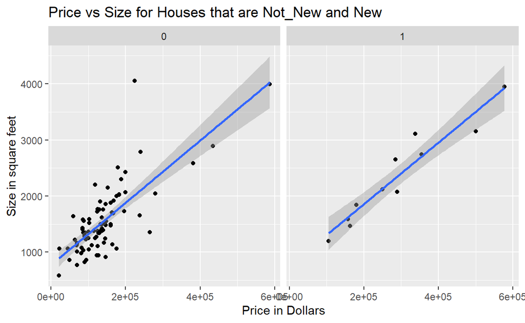

```r
ggplot(new_size_reg,aes(y=Size,x=Price))+
  geom_point()+
  geom_smooth(method="lm",se= T,full_range=T)+
  facet_wrap(.~New)+
  labs(x = "Price in Dollars",y = "Size in square feet",title = "Price vs Size for Houses that are Not_New and New" )
```

**Part F**

Find the predicted selling price for a home of 3000 square feet that is (i) new, (ii) not new.

**Predicted value of new house**

**(i)**

I fit a linear model to determine the predicted selling price of a 3000 sq. ft. new home

```r
new_house_predict<-lm(Price~New+Size+Size*New,data = house.selling.price)
summary(new_house_predict)     #review of output
```

```
Call:
lm(formula = Price ~ New + Size + Size * New, data = house.selling.price)

Residuals:
    Min      1Q  Median      3Q     Max
-175748  -28979   -6260   14693  192519

Coefficients:
              Estimate Std. Error t value Pr(>|t|)
(Intercept) -22227.808  15521.110  -1.432  0.15536
New         -78527.502  51007.642  -1.540  0.12697
Size           104.438      9.424  11.082  < 2e-16 ***
New:Size        61.916     21.686   2.855  0.00527 **
---
Signif. codes:  0 '***' 0.001 '**' 0.01 '*' 0.05 '.' 0.1 ' ' 1

Residual standard error: 52000 on 96 degrees of freedom
Multiple R-squared:  0.7443,    Adjusted R-squared:  0.7363
F-statistic: 93.15 on 3 and 96 DF,  p-value: < 2.2e-16
```

Using our trusty estimated equation we plug in the predictor variables from the

multilinear regression model we calculated earlier. Note for the **new house** we will

use the dummy variable “1” and for **not_new house** we use the dummy variable “0”

Estimated equation:

$\ E$$(y)_{}= -22227.81 -78527.50+104.44(3000)+61.92(3000)$

```r
#Predicting new house price for home with 3000 sq ft.

new_house_predict_est<-(-22227.81-78527.50+104.44*3000+61.92*3000)
print(new_house_predict_est)
```

```
[1] 398324.7
```

New house predicted selling price(3000 sq.ft.) = $398324.70

**(ii)**

We now calculate predicted price for the used aka not_new house house

Estimated equation:

$\ E$$(y)_{}= -22227.81 +104.44(3000)+61.92(0)$

```r
not_new_predict_est<-(-22227.81+104.44*3000+61.92*0)
print(not_new_predict_est)
```

```
[1] 291092.2
```

Not_new house predicted selling price(3000 sq.ft.) = $291092.20

**Part G**

Find the predicted selling price for a home of 1500 square feet that is (i) new, (ii) not new. Comparing to (F), explain how the difference in predicted selling prices changes as the size of home increases.

**(i)**

Predicting selling price of a new house of 1500 square feet

Estimated equation $\ E$$(y)_{}= -22227.81 -78527.50+104.44(1500)+61.92(1500)$

```r
new_house_predict_est<-(-22227.81-78527.50+104.44*1500+61.92*1500)
print(new_house_predict_est)
```

```
[1] 148784.7
```

New house predicted selling price(1500 sq.ft.) = $148784.70

**(ii)**

Estimated equation $\ E$$(y)_{}= -22227.81 +104.44(1500)+61.92(0)$

```r
#Predicted value of used house with 1500 square feet

not_new_predict_est<-(-22227.81+104.44*1500+61.92*0)
print(not_new_predict_est)
```

```
[1] 134432.2
```

Not_new house predicted selling price(1500 sq.ft.) = $134432.20

#### Interpretation:

The predicted selling price difference between a *new* 3000 sq ft and 1500 sq ft *new* house is:

$398324.70-$148784.70 = $249540

Predicted selling price difference between new 3000 sq. ft and 1500 sq ft house

expressed as a percentage

```r
predict_selling_new_diff<-(398324.70 - 148784.70)/((398324.70 + 148784.70)/2)*100
print(predict_selling_new_diff)   #review output
```

```
[1] 91.22124
```

Percentage difference between new 3000 sq.ft. and new 1500 sq.ft. is 91.22%

The predicted selling price difference between a *new* 3000 sq ft and and a *not_new* 3000 sq ft house is:

$398324.70-$291092.20 = $107232.50

The predicted selling price difference between a *not_new* 3000 sq ft and a *not_new* 1500 sq ft house is:

$291092.20-$134432.20 = $156660

Predicted selling price difference between *not_new* 3000 sq. ft and *not_new* 1500 sq ft house as a percentage

```r
predict_selling_price_used_diff<-(291092.20 - 134432.20)/((291092.20 + 134432.20)/2)*100
print(predict_selling_price_used_diff)   #review output
```

```
[1] 73.6315
```

Percentage difference between a *not_new* 3000 sq ft and *not_new* 1500 sq ft house is 73.63%

The predicted selling price difference between a *new* 1500 sq ft and and a not_new 1500 sq ft house is:

$148784.70-$134432.20 = $14352.50

Overall, we see that as the size of a *new* house increases it has more value than comparably sized *used* aka *not_new* houses.

**Part H**

Do you think the model with interaction or the one without it represents the relationship of size and new to the outcome price? What makes you prefer one model over another?

#### Model 1 with interaction term

```r
new_house_predict<-lm(Price~New+Size+Size*New,data = house.selling.price)
summary(new_house_predict)     #review of output
```

```
Call:
lm(formula = Price ~ New + Size + Size * New, data = house.selling.price)

Residuals:
    Min      1Q  Median      3Q     Max
-175748  -28979   -6260   14693  192519

Coefficients:
              Estimate Std. Error t value Pr(>|t|)
(Intercept) -22227.808  15521.110  -1.432  0.15536
New         -78527.502  51007.642  -1.540  0.12697
Size           104.438      9.424  11.082  < 2e-16 ***
New:Size        61.916     21.686   2.855  0.00527 **
---
Signif. codes:  0 '***' 0.001 '**' 0.01 '*' 0.05 '.' 0.1 ' ' 1

Residual standard error: 52000 on 96 degrees of freedom
Multiple R-squared:  0.7443,    Adjusted R-squared:  0.7363
F-statistic: 93.15 on 3 and 96 DF,  p-value: < 2.2e-16
```

#### Model 2 without interaction term

```r
reg_selling_price<-lm(Price~New+Size,data=house.selling.price)
summary(reg_selling_price)        #review of output
```

```
Call:
lm(formula = Price ~ New + Size, data = house.selling.price)

Residuals:
    Min      1Q  Median      3Q     Max
-205102  -34374   -5778   18929  163866

Coefficients:
              Estimate Std. Error t value Pr(>|t|)
(Intercept) -40230.867  14696.140  -2.738  0.00737 **
New          57736.283  18653.041   3.095  0.00257 **
Size           116.132      8.795  13.204  < 2e-16 ***
---
Signif. codes:  0 '***' 0.001 '**' 0.01 '*' 0.05 '.' 0.1 ' ' 1

Residual standard error: 53880 on 97 degrees of freedom
Multiple R-squared:  0.7226,    Adjusted R-squared:  0.7169
F-statistic: 126.3 on 2 and 97 DF,  p-value: < 2.2e-16
```

#### Analysis :

The model with the interaction term has an adjusted $R^{2}$ of 0.7363 compared to an adjusted $R^{2}$ of 0.7169 of the model without one. This suggests that the additional input variable is contributing to the model. Furthermore, comparing the $R^{2}$ between Model 1 and Model 2, the $R^{2}$ predicts that Model 1 is a better model as it carries greater explanatory power (0.7443 in *Model 1* vs. 0.7226 in *Model 2*). Therefore,*Model 1* would be my preference.